# Coursework Report

*N* removed NAs: 2

*N* removed typo: 1

*N* removed <18: 34

*N* total clean: 113

| Group | *N* | *M*<sub>age</sub> | *M*<sub>rating</sub> |
| --- | --- | --- | --- |
| Control | 57 | 20.7 | 5.50 |
| Experim | 56 | 20.8 | 6.43 |

**Main analysis results**

*t*(111) = -5.91, *p* < .001

[interactive chart not shown]

[figure not shown]

[interactive chart not shown]

# Coursework Report

Analysing Data, Spring 2020

# Methods

## Participants

Initially 150 participants participated in this study. 93 participants data was used in the analysis of this study. 57 participants were removed from the study for being too young to participate (under 18 years). All the participants that took place where female. Majority of the participants were Caucasian to control for the effects of ethnicity (Christine et al. 2018). (*M*<sub>age</sub> = 21.376, *SD*<sub>YEARS</sub> = 2.016).

Table 1. Descriptives Statistics by Age

| *M*<sub>YEARS</sub> | *SD*<sub>YEARS</sub> | Min | Max |
| --- | --- | --- | --- |
| 21.4 | 2.02 | 19 | 30 |

Table 1 presents the distribution of the age of the participants data who where used for analysis as well as the range of participants ages (19 - 30 years old).

## Design

The conceptual hypothesis of this study asks if colour influences attractiveness by using a 1 to 9 rating scale in a questionnaire style form of self-report. Participants where shown one picture at a time and then asked to answer the same three question evaluating the degree to which the participant percieves the male in the photograph as attractive. Each picture was had either a white border (control condition) or a red border (experimental condition). The participants were then given out a questionnaire with a mixture of questions and statements: Question 1: “How attractive do you think the person is?” Question 2: “If I were to meet the person in this picture face to face, I would think he is attractive” Question 3: “How pleasant is this person to look at?”

The study was conducted in a laboratory setting, controlling for effects of the three aspect of colour: lightness, chroma and hue (Elliot et al., 2012) ,to the same degree as the original study by ensuring windows were shut and their was a flourescent light overhead of the participant.

In this replication, just as the original study did, I have created a composite score for all three scales of attractiveness, compiling the findings from question 1, question 2 and question 3. This is the score I have used to plot the findings of this replication and in the formation of my t-test in order to interpret the findings of this replication.

# Results

The operational hypothesis questions whether the mean rating of attractiveness of a man is influenced by viewing a different colour frame.

Table 2. Participant Demographics by experimental Condition

| CONDITION | Count | *M*<sub>YEARS</sub> | *SD*<sub>YEARS</sub> |
| --- | --- | --- | --- |
| white | 45 | 21.5 | 2.25 |
| red | 48 | 21.3 | 1.79 |

This table shows the amount of participants whose data was included in the study as well as the mean age and standard devaition.

Table 3. Mean and Standard Deviation for each question

| CONDITION | *M*~Question 1~ | *SD*~Question 1~ | *M*~Question 2~ | *SD*~Question 2~ | *M*~Question 3~ | *SD*~Question 3~ |
| --- | --- | --- | --- | --- | --- | --- |
| white | 5.51 | 1.38 | 1.89 | 1.80 | 5.42 | 1.32 |
| red | 6.60 | 1.12 | 2.01 | 1.32 | 6.42 | 1.33 |

This table resents the individual mean and standard deviation for each question.

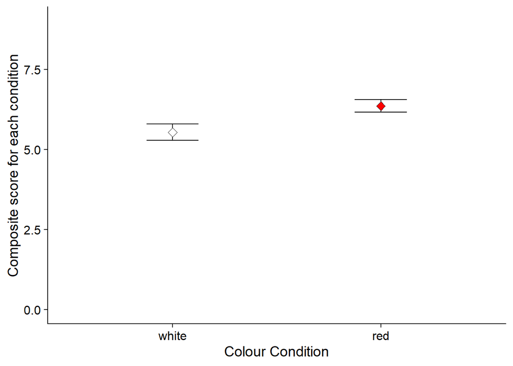

# Discussion

This study looked at more subjective ratings of attraction using a self-report technique where participants would rate their attraction to the man in the photograph on a scale from 1 to 9, assuming that subjective ratings of attraction are not superficial but are an assment of attraction. To explore how valid self-report is as a measure of attraction, further exploring the validity of research into the effects of colour on attractiveness in future studies could investigate whether their is a difference between what people think they are attracted to in comparison to their bodies physiological response of attration which could be measured using Skin Conductance Response (SCR’s) (Lykken and Venables, 1971). This research would build on the research investigating how much insight we actually have into our own experiences such as our physiological attraction to people and in doing so how accurate and thus relaible self-concept is in psychological research into attraction (which could give us further insight into whether our study measures what it is supposed to measure). Research by Kerber and Coles (Kerber and Coles, 1978) explores peoples ability to sense their own physiological responses to attraction by measuring the participants Skin Conductance Response (Dawson et al., 2017) and heart rate using (Montoya et al., 2005) and controlled the physiological feedback a participant would get when they saw slides with pictures of naked females. This research could be critical to develop on because of its likeness to the study I have conducted, their study having critically investigated the reliablity of using a self-report method to rate attractiveness, and just as I did they used a scale of attractiveness to rate participants attraction finding that people’s ratings of attractiveness was influenced by their information based on their sense of physiological feedback.

# References

Dawson, M. E., Schell, A. M., & Filion, D. L. (2017). The electrodermal system. In Handbook of psychophysiology, 4th ed (pp. 217–243). Cambridge University Press.

Elliot, A. J., & Maier, M. A. (2012). Chapter two—Color-in-Context Theory. In P. Devine & A. Plant (Eds.), Advances in Experimental Social Psychology (Vol. 45, pp. 61–125). Academic Press. https://doi.org/10.1016/B978-0-12-394286-9.00002-0

Kerber, K. W., & Coles, M. G. H. (1978). The role of perceived physiological activity in affective judgments. Journal of Experimental Social Psychology, 14(5), 419–433.https://doi.org/10.1016/0022-1031(78)90039-2

Lykken, D. T., & Venables, P. H. (1971). Direct Measurement of Skin Conductance: A Proposal for Standardization. Psychophysiology, 8(5), 656–672. https://doi.org/10.1111/j.1469-8986.1971.tb00501.x

Mohr, C., Jonauskaite, D., Dan-Glauser, E. S., Uusküla, M., & Dael, N. (2018). Unifying research on colour and emotion: Time for a cross-cultural survey on emotion associations to colour terms. In Progress in Colour Studies: Cognition, language and beyond (pp. 209–222). John Benjamins. https://doi.org/10.1075/z.217.11moh

Montoya, P., Campos, J. J., & Schandry, R. (2005). See red? Turn pale? Unveiling Emotions through Cardiovascular and Hemodynamic Changes. The Spanish Journal of Psychology, 8(1), 79–85. https://doi.org/10.1017/S1138741600004984